# for(each) loops

2024-07-12

## Compute function

We use the palmerpenguins dataset to calculate some `glm`.

```r
compute <- function(n) {
  library(palmerpenguins)
  peng <- as.data.frame(penguins) %>%
    mutate(
      species = as.factor(species),
      sex = as.factor(sex)
    ) %>%
    sample_n(100)
  glm(body_mass_g ~ species + sex, data = peng)
}
```

We can run this now and get some result

```r
library(palmerpenguins)
library(dplyr)
compute(1)
```

```
##
## Call:  glm(formula = body_mass_g ~ species + sex, data = peng)
##
## Coefficients:
##      (Intercept)  speciesChinstrap     speciesGentoo           sexmale
##          3364.31             79.29           1360.82            683.97
##
## Degrees of Freedom: 97 Total (i.e. Null);  94 Residual
##   (2 observations deleted due to missingness)
## Null Deviance:       59600000
## Residual Deviance: 8383000   AIC: 1401
```

## Run multiple times parallel

Insteod of running this via `foreach` and `doMC`, we now use `clustermq`. We will have to tell `clustermq` that we want to use SLURM and add a template which will keep all SLURM specific stuff contained.

```r
options(
    clustermq.scheduler = "slurm",
    clustermq.template = "slurm.tmpl"
)
```

We now load the library `clustermq` and `foreach` and register `clustermq` as parallel backend

```r
library(clustermq)
library(foreach)
library(doRNG)
# Register parallel backend to foreach
register_dopar_cmq(
  n_jobs = 8,
  log_worker = FALSE,
  verbose = FALSE,
  chunk_size = 10
)
```

Finally we run the same code as in the previous example

```r
library(dplyr)
samples=1000
res<-foreach(i = 1:samples) %dorng% {
  compute(i)
}
```

```
## Master: [8.2 secs 28.4% CPU]; Worker: [avg 79.5% CPU, max 267 Mb]
```

## Postprocessing

```r
post_processing <- function(res, samples) {
  # create new data
  new_dat <- tibble::tribble(~ species, ~ sex, "Chinstrap", "male")

  # create prediction for each of the models
  library(purrr)
  library(tibble)
  preds <- tibble(mass = map_dbl(res, predict, new_dat))

  # plot the result
  library(ggplot2)
  ggplot(preds, aes(x = mass)) +
    geom_histogram(bins = samples / 50) +
    ggtitle("Ensemble model prediction of mass of male Chinstrap penguins")

}
```

Let’s run it on our current results

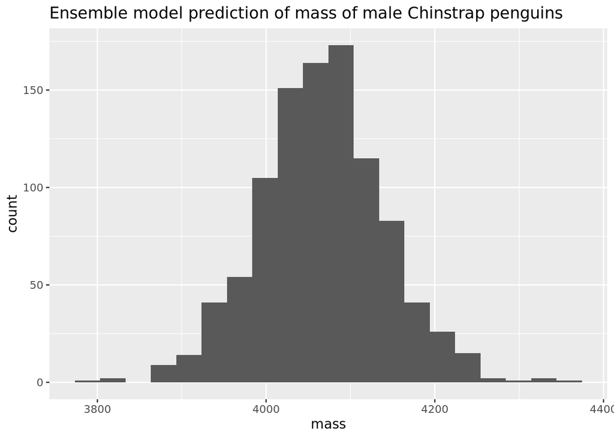

```r
post_processing(res,samples)
```

## Scalability study

```r
cores_available<-10
times <- c()
for (i in 1:cores_available)
{
  # Register parallel backend to foreach
register_dopar_cmq(
  n_jobs = i,
  log_worker = FALSE,
  verbose = FALSE,
  chunk_size = 100
)
  set.seed(1234)
  samples = 10000
  times[i] <- system.time(foreach(j = 1:samples) %dorng% {
    compute(j)
  })[3]
  gc()
}
```

```
## Master: [1.6 mins 16.1% CPU]; Worker: [avg 81.8% CPU, max 336.6 Mb]
```

```
## Master: [49.6 secs 20.6% CPU]; Worker: [avg 84.5% CPU, max 336.6 Mb]
```

```
## Master: [38.2 secs 31.3% CPU]; Worker: [avg 76.9% CPU, max 336.7 Mb]
```

```
## Master: [26.2 secs 25.3% CPU]; Worker: [avg 89.9% CPU, max 336.7 Mb]
```

```
## Master: [21.7 secs 30.0% CPU]; Worker: [avg 90.8% CPU, max 336.7 Mb]
```

```
## Master: [19.7 secs 32.3% CPU]; Worker: [avg 91.0% CPU, max 336.6 Mb]
```

```
## Master: [18.5 secs 34.9% CPU]; Worker: [avg 90.5% CPU, max 336.7 Mb]
```

```
## Master: [17.4 secs 37.5% CPU]; Worker: [avg 90.3% CPU, max 310.9 Mb]
```

```
## Master: [16.0 secs 41.6% CPU]; Worker: [avg 90.6% CPU, max 310.2 Mb]
```

```
## Master: [15.8 secs 42.8% CPU]; Worker: [avg 91.0% CPU, max 310.5 Mb]
```

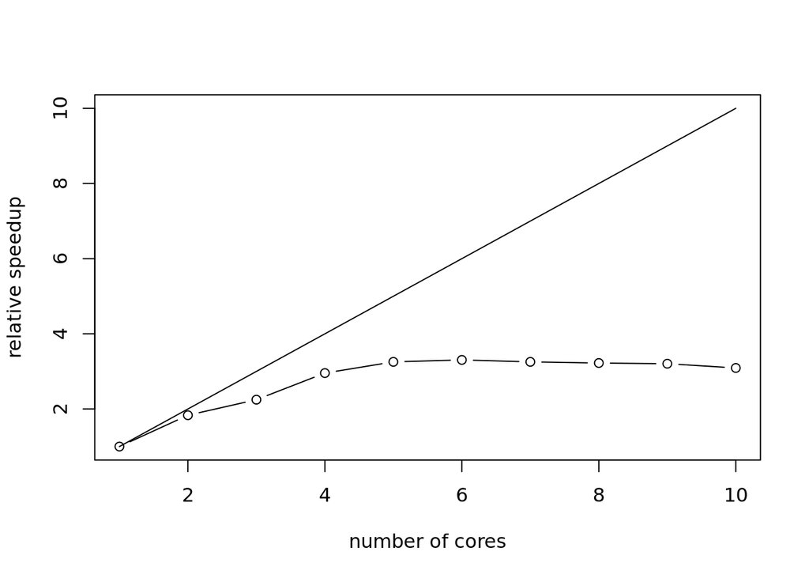

```r
plot(seq(1:cores_available),seq(1:cores_available),xlab="number of cores",ylab="relative speedup",type="l")
lines(times[1]/times,type="c")
lines(times[1]/times,type="p")
```

## main differences to `doMC`

- no monolithic jobs, each `n_jobs` is a separate SLURM job. Even if you wanted to run on 32 cores but only 23 are available, `clustermq` will still run and adaptively use only the running jobs for the calculation. This will still give you some results although not with the desired performance. If more cores become available, the will automatically be used
- `clustermq` jobs can be launched directly from the R console in the IDE session.